# Geocoding Missing Postal Codes

Christopher Belanger

2020-12-02 15:34:24

# Introduction

The Ottawa Neighbourhood Study (ONS) produced a single-link indicator (SLI) file and a weighted-value file (collectively “the crosswalks”) that map local postal codes to one or more ONS neighbourhoods. The Institute for Clinical Evaluative Sciences (ICES) is collaborating with Ottawa Public Health (OPH) to map COVID-19 data by postal code, and ONS has shared its crosswalks with OPH and ICES to help.

ICES has shared a list of postal codes present in its COVID data that are missing from ONS’s SLI and weighted file.

This document describes the process to geocode those missing postal codes and add them to the pre-existing crosswalks.

# Loading the Data

## ICES Data

Load ICES’s list of postal codes:

```r
pcodes_ices <- readxl::read_xlsx("../04 - Missing postal codes/data/Ottawa PHU_unknown neighbourhood_pstlcodes.xlsx", col_names = "FALSE") %>%
  rename(postal_code = 1)
```

ICES’s data has 3760 postal codes:

```r
pcodes_ices %>%
  distinct() %>%
  nrow()
```

```
## [1] 3760
```

At a glance, here are the first 10 postal codes ICES listed as missing in alphabetical order:

```r
pcodes_ices %>%
  arrange(postal_code) %>%
  head(10)
```

```
## # A tibble: 10 x 1
##    postal_code
##    <chr>
##  1 K0A1A0
##  2 K0A1B0
##  3 K0A1K0
##  4 K0A1K9
##  5 K0A1L0
##  6 K0A1L9
##  7 K0A1T0
##  8 K0A1V0
##  9 K0A1X0
## 10 K0A1Z0
```

## The SLI

Load the SLI and display the first 10 rows:

```r
pcodes_sli <- read_csv("results/LDUs_all_ONS_SLI.csv")
pcodes_sli %>%
  head(10)
```

```
## # A tibble: 10 x 2
##    POSTALCODE ONS_ID
##    <chr>       <dbl>
##  1 K0A1A0         30
##  2 K0A1B0         67
##  3 K0A1E0        919
##  4 K0A1G0        922
##  5 K0A1K0        918
##  6 K0A1L0        911
##  7 K0A1T0         35
##  8 K0A1V0        918
##  9 K0A1X0        922
## 10 K0A2A0        955
```

**The first few of ICES’s “missing” postal codes are present in the SLI**, suggesting that not all of the codes ICES identified are actually missing. However, there may be other missing codes.

## Cleaned Postal Code Shapefile

For our analysis, ONS used a “cleaned” shapefile that only includes Ontario and combines multi-part postal codes into single (possibly disconnected) shapes. Load the LDU/postal code shapefile and make a quick plot:

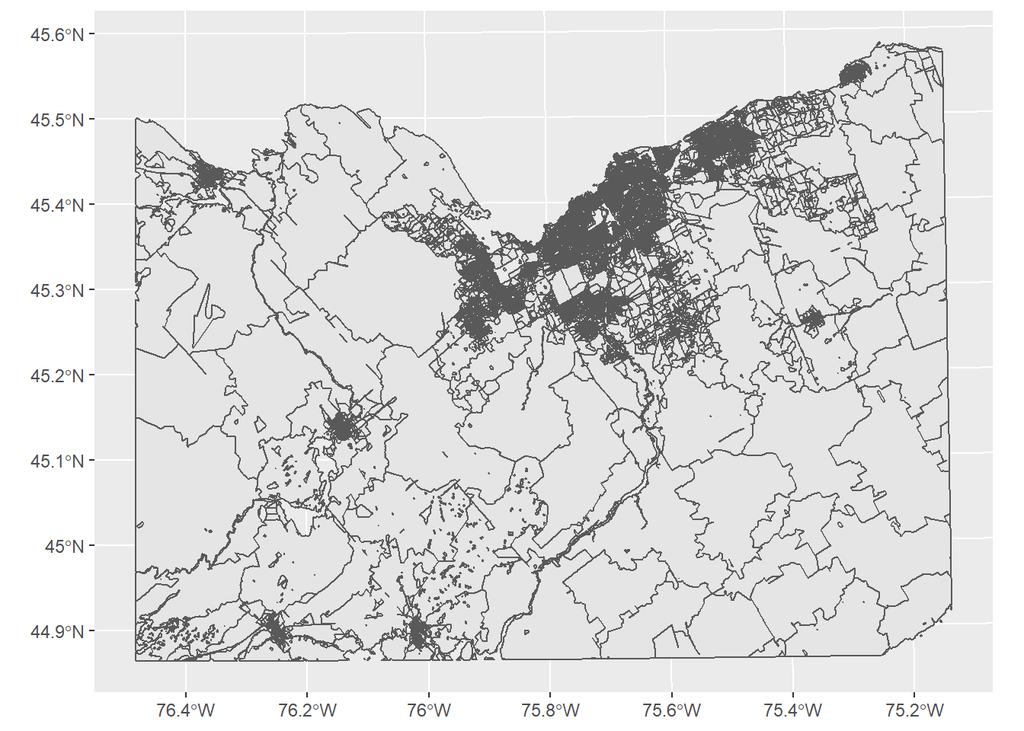

```r
ldus <- read_sf("../1 - New/shapefiles/LDU_union.shp") %>%
   sf::st_transform(32189)

ldus %>%
  ggplot() +
  geom_sf()
```

## Original DMTI Postal Code Shapefile

For validation, we load the original DMTI shapefile as well. This shapefile includes all postal codes in a bounding box that contains more than Ottawa. The image has more lines because many postal codes are divided into more than one polygon.

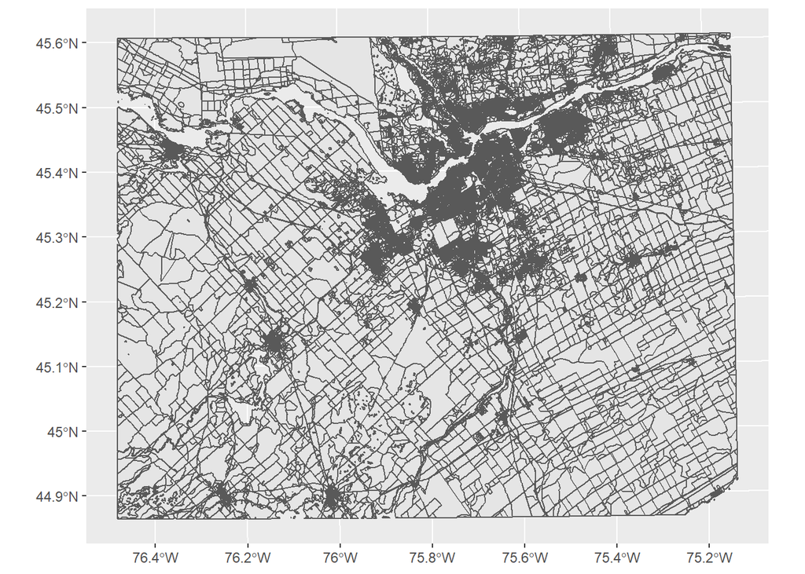

```r
ldus_dmti <- read_sf("../1 - New/shapefiles/DMTI_2019_CMPCS_LocalDeliveryUnitsRegion.shp") %>%
  sf::st_transform(32189)

ldus_dmti %>%
  ggplot() +
  geom_sf()
```

## Identify Missing Codes

There are 741 postal codes that are in ICES’ list but not in the SLI:

```r
missing_codes <- pcodes_ices %>%
  filter(!postal_code %in% pcodes_sli$POSTALCODE)

missing_codes %>%
  distinct() %>%
  nrow()
```

```
## [1] 741
```

# Geocoding the Missing Postal Codes

## Setting Up the Function

```r
# load the api key (no, this value isn't synced on github :)
api_key <- read_file("../../999. Often-used datafiles/chris_google_api/chris_google_api_key.csv")

# function to query Google Maps Geocoding API
gmap_geocode <- function(address = "1243 Willowdale Ave, Ottawa, ON", verbose = FALSE, wait_nicely = TRUE, api_key = NA) {
  # must give an api key
  if (is.na(api_key)) stop ("Please provide a valid Google Cloud API key. Get one for free here: https://cloud.google.com/free/")

  # we're only supposed to do 50 requests per second, as per the API terms of use:
  # https://developers.google.com/maps/documentation/geocoding/usage-and-billing
  # To be super nice, we'll only do 40 per second
  if (wait_nicely) Sys.sleep(60/4000)


  # here's the base url to the api
  base_url <- "https://maps.googleapis.com/maps/api/geocode/json"

  # set up a url object using the base url
  url <- parse_url(base_url)

  # tell the url object we'd like to query that object
  url$query <- list(address = address,
                    key = api_key)

  # make a url out of all this information
  url_full <- build_url(url)

  # now try to get it
  q <- httr::GET(url=url_full)

  # give updates to the console if we want them
  if (verbose) {
    message (paste0("* Address: ", address))
    message (paste0("   Status code: ", q$status_code))
  }

  lat <- NA
  lng <- NA
  # if we got a good response code and if we got at least one result
  if (q$status_code == 200 & length(content(q)$results) > 0){
    # extract the latitude and longitude
    latlon <- content(q)$results[[1]]$geometry$location
    lat <- latlon$lat
    lng <- latlon$lng
  }

  return (tibble (lat=lat, lng=lng))
}
```

## Testing the Function

Test the function on just a postal code: mine, K1H7S5. The result looks good.

```r
test_geocode <- gmap_geocode(address = "K1H7S5", api_key = api_key)

test_geocode %>%
  leaflet() %>%
  addTiles() %>%
  addMarkers()
```

[interactive chart not shown]

Next we’ll try geocoding 10 randomly selected missing postal codes:

```r
set.seed(1234)
test_codes <- missing_codes %>%
  slice_sample(n=10)

test_geocodes <- test_codes %>%
  mutate(geo = purrr::map(postal_code, gmap_geocode, verbose = FALSE, api_key = api_key)) %>%
  unnest(cols = "geo")

test_geocodes %>%
  drop_na() %>%
  nrow()
```

```
## [1] 6
```

On December 2, Google found results for 6 out of 10 postal codes. If we plot these postal codes, we see they’re distributed across Ottawa:

```r
test_geocodes %>%
  leaflet() %>%
  addTiles() %>%
  addMarkers(label = test_geocodes$postal_code)#lat= test_geocodes$lat, lng = test_geocodes$lng)
```

[interactive chart not shown]

We can use a Google Search to inspect a missing and un-geocodable postal code:

```r
test_geocodes %>%
  filter(is.na(lat))
```

```
## # A tibble: 4 x 3
##   postal_code   lat   lng
##   <chr>       <dbl> <dbl>
## 1 K1R0E1         NA    NA
## 2 K1G1S0         NA    NA
## 3 K2T0R2         NA    NA
## 4 K1V1N2         NA    NA
```

Google gives about 22 results for “K1V1N2”, all of which seem to be quite old (e.g. an Ottawa Citizen article from 2001). This suggests that it was once an active postal code, but is no longer.

### Geocoding all the Missing Postal Codes

This code block uses Google’s geocoding API. Since Google limits usage, I ran it on December 2, 2020 and saved the results.

```r
missing_latlons <- missing_codes %>%
  mutate(geo = purrr::map(postal_code, gmap_geocode, verbose = TRUE, api_key = api_key)) %>%
  unnest(cols = "geo")

# save so we don't need to run the expensive geocoding again
missing_latlons %>%
  save(file = "results/latlons-missing.RData")

missing_latlons %>%
  write_csv("results/missing_latlons_(2020.12.02).csv")

# print a summary
missing_latlons %>%
  drop_na()
```

Plotting the results we see one obvious error in Kansas, but if you zoom in on Ottawa many of the codes are clustered close to each other. This suggests that there may be updates to the postal codes that aren’t reflected in the DMTI shapefile.

```r
missing_latlons <- read_csv("results/missing_latlons_(2020.12.02).csv")

missing_latlons %>%
  leaflet() %>%
  addTiles() %>%
  addMarkers(label = missing_latlons$postal_code)
```

[interactive chart not shown]

### Assigning Postal Codes to Neighbourhoods

Here we define a helper function to do a spatial join:

```r
# function to get the neighbourhood each point is in
get_pts_neighbourhood <- function(pts, pgon){
  # check input validity
  if (!"sf" %in% class(pts)) stop("Invalid input: pts must have class 'sf', e.g. a shapefile loaded with sf::read_sf().")
  if (!"sf" %in% class(pgon)) stop("Invalid input: pgon must have class 'sf', e.g. a shapefile loaded with sf::read_sf().")

  # make sure the two datasets have the same CRS
  if (sf::st_crs(pts) != sf::st_crs(pgon)) pts <- sf::st_transform(pts, sf::st_crs(pgon))

  # do a spatial join. #
  results <- sf::st_join(pts, pgon)

  return (results)
}
```

And we convert the list of lat/lngs to spatial objects and plot to make sure it’s done correctly:

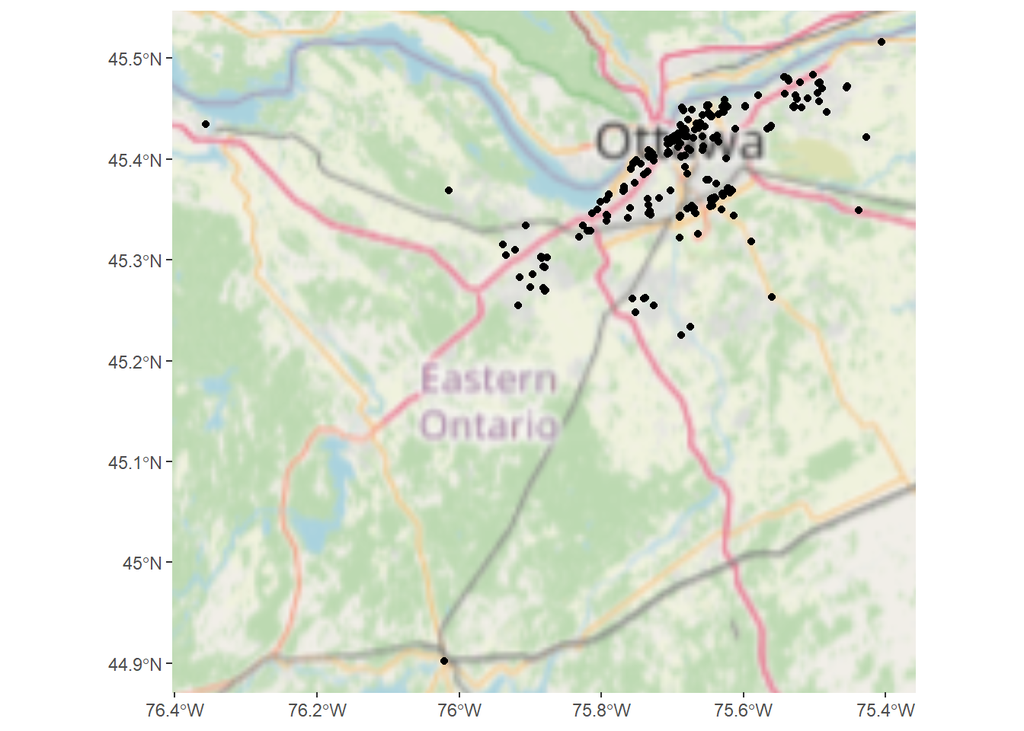

```r
missing_shp <- missing_latlons %>%
  drop_na() %>%
  filter(postal_code != "K2B") %>%
  sf::st_as_sf(coords = c("lng","lat"), crs = "WGS84")

missing_shp %>%
  ggplot() +
  ggspatial::annotation_map_tile() +
  geom_sf()
```

Then we map each point to its ONS neighbourhood and plot to make sure it makes sense:

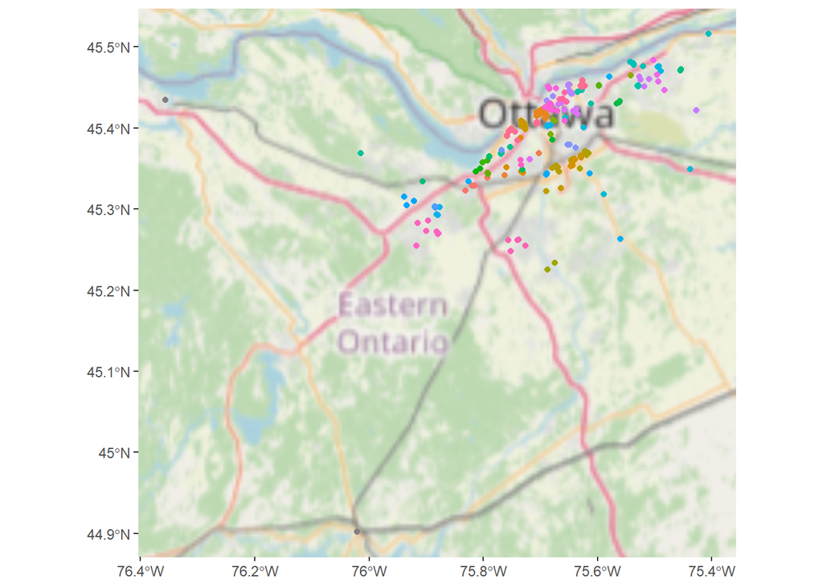

```r
missing_shp_nbhds <- get_pts_neighbourhood(pts = missing_shp, pgon = ons_shp)

missing_shp_nbhds %>%
  ggplot(aes(colour = as.factor(ONS_ID))) +
  ggspatial::annotation_map_tile() +
  geom_sf() +
  theme(legend.position = "none")
```

It all looks good.

### Saving the New Data

So we’ll save the neighbourhood data for the postal codes we found, and we’ll save a separate list of the postal codes we couldn’t find.

**NOTE** that there was also one invalid postal code: “K2B”.

```r
# save the results we found

# weighted style (basically the same as sli since all the weights are 1)
missing_long <- missing_shp_nbhds %>%
  sf::st_set_geometry(NULL) %>%
  select(POSTALCODE = postal_code,
         ONS_ID) %>%
  filter(!is.na(ONS_ID)) %>%
  mutate(pct_intersect = 1)

# single-link indicator style
missing_sli <- missing_long %>%
  select(-pct_intersect)


missing_shp_nbhds %>%
  sf::st_set_geometry(NULL) %>%
  select(POSTALCODE = postal_code,
         ONS_ID) %>%
  write_csv("results/missing_postal_codes_geocodable_sli_(2020.12.02).csv")

# weighted style (basically the same since all the weights are 1)
missing_shp_nbhds %>%
  sf::st_set_geometry(NULL) %>%
  select(POSTALCODE = postal_code,
         ONS_ID) %>%
  mutate(pct_intersect = 1) %>%
  write_csv("results/missing_postal_codes_geocodable_weighted_(2020.12.02).csv")


# save the results we couldn't find (or that are outside ONS boundaries) in a separate list
missing_latlons %>%
  filter(is.na(lat) | is.na(lng)) %>%
  mutate (ONS_ID = NA) %>%
  bind_rows(
    missing_shp_nbhds %>%
  sf::st_set_geometry(NULL) %>%
  select(POSTALCODE = postal_code,
         ONS_ID) %>%
  filter(is.na(ONS_ID))
  ) %>%
  select(postal_code, ONS_ID) %>%
  write_csv("results/missing_postal_codes_ungeocodable_(2020.12.02).csv")
```

### Saving New with Old Data

Here we create augmented versions of the weighted file and the SLI file, saved separately and datestamped.

```r
ldus_long <- read_csv("results/LDUs_all_ONS_long.csv")

sli_long <- read_csv("results/LDUs_all_ONS_SLI.csv")

ldus_augmented <- bind_rows(ldus_long,
          missing_long)

ldus_augmented %>%
  write_csv("results/LDUS_ONS_augmented_long_(2020.12.02).csv")

sli_augmented <- bind_rows(sli_long,
                           missing_sli)

sli_augmented %>%
  write_csv("results/LDUS_ONS_augmented_SLI_(2020.12.02).csv")
```